# Association rules

Movie recommender systems

student name

2018-07-20 23:08:53

> با استفاده از داده نظرهای فیلم به سوالات زیر پاسخ دهید.

```r
# Read Data
library(readr)
library(dplyr)
library(arules)
```

```r
library(reshape2)
library(Matrix)
library(stringr)
library(stringdist)
library(ggplot2)

# Movies
movie = read_delim('ml-10M100K/movies.dat',delim = "::" ,col_names = c("MovieID",NA,"Title",NA,"Genres"))
movie = movie %>% select(1,3,5)
head(movie)
```

```
## # A tibble: 6 x 3
##   MovieID Title                              Genres
##     <int> <chr>                              <chr>
## 1       1 Toy Story (1995)                   Adventure|Animation|Children…
## 2       2 Jumanji (1995)                     Adventure|Children|Fantasy
## 3       3 Grumpier Old Men (1995)            Comedy|Romance
## 4       4 Waiting to Exhale (1995)           Comedy|Drama|Romance
## 5       5 Father of the Bride Part II (1995) Comedy
## 6       6 Heat (1995)                        Action|Crime|Thriller
```

```r
# Tags
tag = read_delim('ml-10M100K/tags.dat',delim = "::" ,col_names = c("UserID",NA,"MovieID",NA,"Tag",NA,"Timestamp"))
tag = tag %>% select(1,3,5,7)
head(tag)
```

```
## # A tibble: 6 x 4
##   UserID MovieID Tag              Timestamp
##    <int>   <int> <chr>                <int>
## 1     15    4973 excellent!      1215184630
## 2     20    1747 politics        1188263867
## 3     20    1747 satire          1188263867
## 4     20    2424 chick flick 212 1188263835
## 5     20    2424 hanks           1188263835
## 6     20    2424 ryan            1188263835
```

```r
# Ratings
rating = read_delim('ml-10M100K/ratings.dat',delim = "::" ,col_names = c("UserID",NA,"MovieID",NA,"Rating",NA,"Timestamp"))
rating = rating %>% select(1,3,5,7)
head(rating)
```

```
## # A tibble: 6 x 4
##   UserID MovieID Rating Timestamp
##    <int>   <int>  <dbl>     <int>
## 1      1     122   5.00 838985046
## 2      1     185   5.00 838983525
## 3      1     231   5.00 838983392
## 4      1     292   5.00 838983421
## 5      1     316   5.00 838983392
## 6      1     329   5.00 838983392
```

۱. آماره های زیر را بیابید. الف. محبوب ترین فیلم کدام است؟ ب. بیشترین نظرات درباره چه فیلمی داده شده است؟ پ. منفورترین فیلم کدام است؟ ت. تعداد فیلم های ساخته شده در هر سال ث. در هر سالی مردم به چه ژانری علاقه مند بوده اند.

برای پیدا کردن محبوب ترین و منفور ترین فیلم در هر قسمت ابتدا باید به این نکته توجه کرد که تعداد رای ها از میزانی کمتر نباشد تا میانگین ریتینگ مربوط به آن معنی دار باشد . در اینجا با توجه به حداکثر تعداد رای 34864 رای و میانگین ۱۰۰۰ رای . تعداد حداقل رای لازم برای بدست آوردن محبوب ترین و منفور ترین را ۲۰۰۰ قرار دادم .

```r
rating %>% filter(MovieID %in% movie$MovieID) %>% group_by(MovieID) %>% summarise(mean_rate=mean(Rating,na.rm=T),count=n()) %>% filter(count >2000)%>% group_by(MovieID) %>%
  mutate(movie_name = movie$Title[movie$MovieID==MovieID]) %>% arrange(-count)-> mean_rate_count
mean_rate_count %>% arrange(-mean_rate)
```

```
## # A tibble: 1,241 x 4
## # Groups:   MovieID [1,241]
##    MovieID mean_rate count movie_name
##      <int>     <dbl> <int> <chr>
##  1     318      4.46 31126 Shawshank Redemption, The (1994)
##  2     858      4.42 19814 Godfather, The (1972)
##  3      50      4.37 24037 Usual Suspects, The (1995)
##  4     527      4.36 25777 Schindler's List (1993)
##  5     922      4.32  3255 Sunset Blvd. (a.k.a. Sunset Boulevard) (1950)
##  6     912      4.32 12507 Casablanca (1942)
##  7     904      4.32  8825 Rear Window (1954)
##  8    3435      4.32  2403 Double Indemnity (1944)
##  9    2019      4.31  5751 Seven Samurai (Shichinin no samurai) (1954)
## 10    1212      4.31  3265 Third Man, The (1949)
## # ... with 1,231 more rows
```

محبوب ترین فیلم Shawshank Redemption, The (1994 با ریتینگ ۴.۴۵ و تعداد 31126 منفور ترین : To Wong Foo, Thanks for Everything! Julie Newmar (1995) با ریتینگ۳.۱۲ و تعداد ۳۲۳۴ رای

*بیشترین نظرات* بیشترین نظرات با شمردن تعداد ریتنگ ها برای pulp fiction داده شده . *تعداد فیلم های ساخته شده در هر سال*

```r
library(anytime)
movie$year = as.numeric(str_sub( str_trim(movie$Title) ,start = -5,end = -2))
```

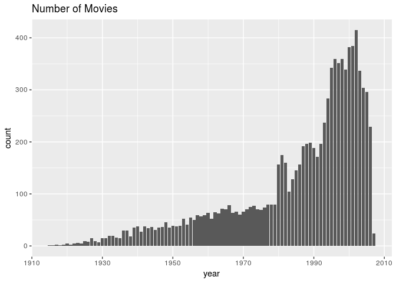

```r
movie <- movie[-which(is.na(movie$year)),]
movie <- movie[movie$year>1800,]
ggplot(movie,aes(x=year)) + geom_bar() + ggtitle("Number of Movies")
```

۲. ژانر فیلم ها را استخراج نمایید. سپس آماره های زیر را استخراج نمایید. الف. نمودار ستونی تعداد فیلم های هر ژانر ب. نمودار همبستگی ژانرها پ. متوسط امتیاز به هر ژانر ت. دوران طلایی فیلم سازی

الف. نمودار ستونی تعداد فیلم های هر ژانر *finding all generes* i remove rare genres in here:

```r
genre = unique(unlist(str_split(movie$Genres,"\\|")))
genre = genre[!genre %in% c("IMAX","(no genres listed)",NA)]
```

adding genre to each movie:

```r
temp_mo <-movie
for (g in genre){
  temp_mo %>% mutate(!!g:=grepl(g,Genres)) -> temp_mo
  temp_mo[temp_mo==FALSE]<-0
  temp_mo[temp_mo==TRUE] <-1
}
head(temp_mo)
```

```
## # A tibble: 6 x 22
##   MovieID Title  Genres   year Adventure Animation Children Comedy Fantasy
##     <dbl> <chr>  <chr>   <dbl>     <dbl>     <dbl>    <dbl>  <dbl>   <dbl>
## 1    1.00 Toy S… Advent…  1995      1.00      1.00     1.00   1.00    1.00
## 2    2.00 Juman… Advent…  1995      1.00      0        1.00   0       1.00
## 3    3.00 Grump… Comedy…  1995      0         0        0      1.00    0
## 4    4.00 Waiti… Comedy…  1995      0         0        0      1.00    0
## 5    5.00 Fathe… Comedy   1995      0         0        0      1.00    0
## 6    6.00 Heat … Action…  1995      0         0        0      0       0
## # ... with 13 more variables: Romance <dbl>, Drama <dbl>, Action <dbl>,
## #   Crime <dbl>, Thriller <dbl>, Horror <dbl>, Mystery <dbl>,
## #   `Sci-Fi` <dbl>, Documentary <dbl>, War <dbl>, Musical <dbl>,
## #   `Film-Noir` <dbl>, Western <dbl>
```

ب. نمودار همبستگی ژانرها

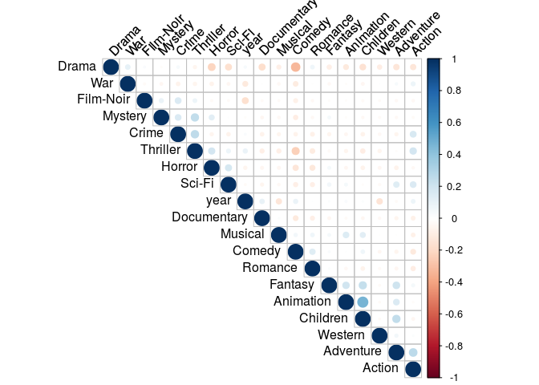

```r
library(corrplot)
temp_mo %>% select(-c(1:3)) %>% as.matrix() ->temp_mat
res <- cor(temp_mat)
corrplot(res, type = "upper", order = "hclust",
         tl.col = "black", tl.srt = 45)
```

پ. متوسط امتیاز به هر ژانر I use mean rate of each movie in here :

```r
rating %>% filter(MovieID %in% movie$MovieID) %>% group_by(MovieID) %>% summarise(mean_rate=mean(Rating,na.rm=T))%>% group_by(MovieID) %>%
  mutate(movie_name = movie$Title[movie$MovieID==MovieID])-> mean_rate_count
mean_rate_count %>% arrange(-mean_rate)
```

```
## # A tibble: 9,334 x 3
## # Groups:   MovieID [9,334]
##    MovieID mean_rate movie_name
##      <int>     <dbl> <chr>
##  1   33264      5.00 Satan's Tango (Sátántangó) (1994)
##  2   42783      5.00 Shadows of Forgotten Ancestors (1964)
##  3   51209      5.00 Fighting Elegy (Kenka erejii) (1966)
##  4    4454      4.75 More (1998)
##  5    5194      4.75 Who's Singin' Over There? (a.k.a. Who Sings Over The…
##  6   26048      4.75 Human Condition II, The (Ningen no joken II) (1959)
##  7   26073      4.75 Human Condition III, The (Ningen no joken III) (1961)
##  8    5849      4.67 I'm Starting From Three (Ricomincio da Tre) (1981)
##  9   32657      4.57 Man Who Planted Trees, The (Homme qui plantait des a…
## 10    3226      4.50 Hellhounds on My Trail (1999)
## # ... with 9,324 more rows
```

```r
temp_mo %>% filter(MovieID %in% mean_rate_count$MovieID) %>% group_by(MovieID) %>%  mutate(rate=mean_rate_count$mean_rate[mean_rate_count$MovieID==MovieID]) ->mean_rate_genre

genre_rate <-c(1:length(genre))
names(genre_rate) <- genre
genre
```

```
##  [1] "Adventure"   "Animation"   "Children"    "Comedy"      "Fantasy"
##  [6] "Romance"     "Drama"       "Action"      "Crime"       "Thriller"
## [11] "Horror"      "Mystery"     "Sci-Fi"      "Documentary" "War"
## [16] "Musical"     "Film-Noir"   "Western"
```

```r
for (g in genre){
  genre_rate[g] =
    mean(mean_rate_genre[mean_rate_genre[,g]==1,]$rate,na.rm=T)
}

genre_rate
```

```
##   Adventure   Animation    Children      Comedy     Fantasy     Romance
##    3.170574    3.265360    3.026128    3.127134    3.207771    3.302077
##       Drama      Action       Crime    Thriller      Horror     Mystery
##    3.352103    3.065237    3.298670    3.192632    2.826850    3.336443
##      Sci-Fi Documentary         War     Musical   Film-Noir     Western
##    2.956946    3.453024    3.475385    3.268971    3.722756    3.339929
```

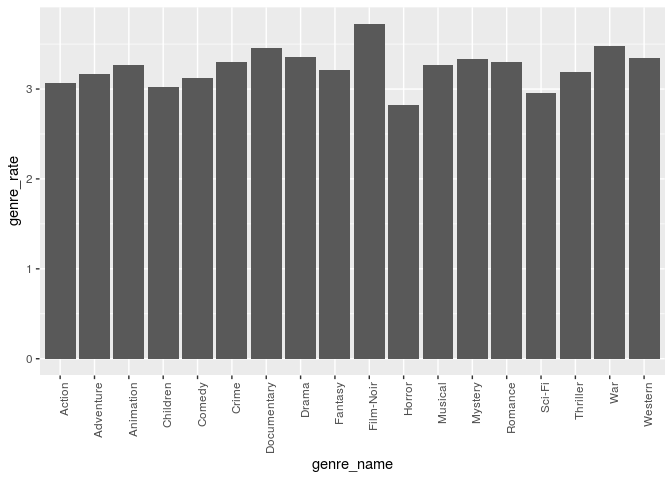

```r
data.frame(genre_name=genre,genre_rate=genre_rate) %>%  ggplot() + geom_bar(aes(x = genre_name, y = genre_rate),stat ="identity" )+
  theme(axis.text.x = element_text(angle = 90, hjust = 1))
```

۳. نمودار ابر لغات را بر حسب کلمات عنوان فیلم ها رسم نمایید.

```r
library("tm")
```

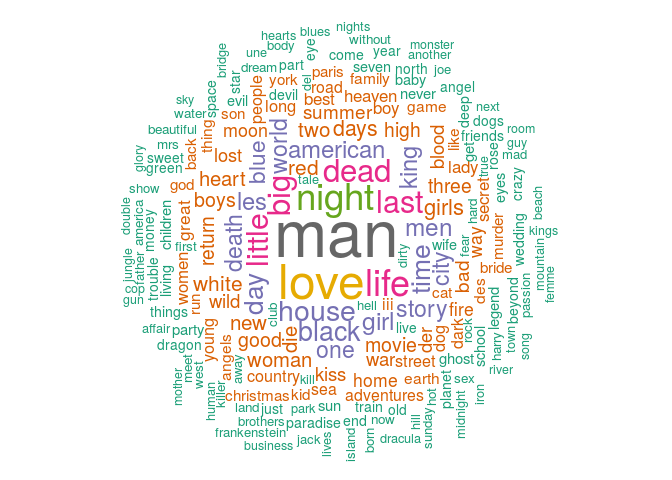

```r
library("SnowballC")
library("wordcloud")
library("RColorBrewer")
movie_name <- movie$Title
docs <- Corpus(VectorSource(movie_name))
toSpace <- content_transformer(function (x , pattern ) gsub(pattern, " ", x))
docs <- tm_map(docs, toSpace, "/")
docs <- tm_map(docs, toSpace, "@")
docs <- tm_map(docs, toSpace, "\\|")

#### clean names
# Convert the text to lower case
docs <- tm_map(docs, content_transformer(tolower))
# Remove numbers
docs <- tm_map(docs, removeNumbers)
# Remove english common stopwords
docs <- tm_map(docs, removeWords, stopwords("english"))
# Remove your own stop word
# specify your stopwords as a character vector
docs <- tm_map(docs, removeWords, c("blabla1", "blabla2"))
# Remove punctuations
docs <- tm_map(docs, removePunctuation)
# Eliminate extra white spaces
docs <- tm_map(docs, stripWhitespace)
# Text stemming
# docs <- tm_map(docs, stemDocument)

dtm <- TermDocumentMatrix(docs)
m <- as.matrix(dtm)
v <- sort(rowSums(m),decreasing=TRUE)
d <- data.frame(word = names(v),freq=v)

set.seed(1234)
wordcloud(words = d$word, freq = d$freq, min.freq = 1,
          max.words=200, random.order=FALSE, rot.per=0.35,
          colors=brewer.pal(8, "Dark2"))
```

۴. با استفاده از قوانین همبستگی یک توصیه گر برای فیلم ها بسازید. شبیه ترین فیلم ها به لیست زیر را پیدا کنید.

- Castle in the Sky (1986)
- Cast Away (2000)
- No Country for Old Men (2007)
- Memento (2000)

I use method descaussed in https://rpubs.com/vitidN/203264.

```r
er_movie_id = which(is.na(movie$year))
rating = rating %>% filter(! MovieID %in% er_movie_id )
rating <- rating[complete.cases(rating),]
#convert rating-per-row dataframe into sparse User-Item matrix
rating$MovieID = as.factor(rating$MovieID)
rating$UserID = as.factor(rating$UserID)


aggrData <- split(rating$MovieID,rating$UserID)

listData <- list()
for (i in 1:length(aggrData)) {
    listData[[i]] <- as.character(aggrData[[i]][!duplicated(aggrData[[i]])])
}

trnsData <- as(listData,"transactions")

rule_param = list(
    supp = 0.001,
    conf = 0.7,
    maxlen = 2
)
assoc_rules = apriori(trnsData,parameter = rule_param)
```

```
## Apriori
##
## Parameter specification:
##  confidence minval smax arem  aval originalSupport maxtime support minlen
##         0.7    0.1    1 none FALSE            TRUE       5   0.001      1
##  maxlen target   ext
##       2  rules FALSE
##
## Algorithmic control:
##  filter tree heap memopt load sort verbose
##     0.1 TRUE TRUE  FALSE TRUE    2    TRUE
##
## Absolute minimum support count: 69
##
## set item appearances ...[0 item(s)] done [0.00s].
## set transactions ...[10677 item(s), 69878 transaction(s)] done [1.92s].
## sorting and recoding items ... [6605 item(s)] done [0.35s].
## creating transaction tree ... done [0.07s].
## checking subsets of size 1 2
```

```
##  done [4.99s].
## writing ... [186918 rule(s)] done [0.16s].
## creating S4 object  ... done [0.04s].
```

```r
assoc_rules = subset(assoc_rules, lift >= 4.323)
assoc_rules = as(assoc_rules,"data.frame")
```

```r
rules = sapply(assoc_rules$rules,function(x){
    x = gsub("[\\{\\}]", "", regmatches(x, gregexpr("\\{.*\\}", x))[[1]])
    x = gsub("=>",",",x)
    x = str_replace_all(x," ","")
    return( x )
})

rules = as.character(rules)
rules = str_split(rules,",")

data_rules<- do.call(rbind.data.frame, rules)
colnames(data_rules) <-c('left','right')
```

for each film in top list I find rules that contain in left of rules. then by finding intercection of all movies that they recommend I find best movies for these 4 movie .i didnt find * No Country for Old Men (2007) in movies so i remove it.

- Castle in the Sky (1986)
- Cast Away (2000)
- Memento (2000)

```r
m <- c('Castle in the Sky (Tenkû no shiro Rapyuta) (1986)','Cast Away (2000)','No Country for Old Men (2007)','Memento (2000)')
movie %>%  filter (Title %in%m) -> temp
l <- list()
count <- 1
for (id in temp$MovieID){
    data_rules %>% filter(left==id) -> data_temp
    l[[count]] <- data_temp$right
    count <- count + 1
}
#in here only memnto recommend sth
l_id <- l[[3]]
movie %>% filter(MovieID %in% l_id)
```

```
## # A tibble: 4 x 4
##   MovieID Title                            Genres                     year
##     <int> <chr>                            <chr>                     <dbl>
## 1    3000 Princess Mononoke (Mononoke-him… Action|Adventure|Animati…  1997
## 2    4973 Amelie (Fabuleux destin d'Améli… Comedy|Romance             2001
## 3    5618 Spirited Away (Sen to Chihiro n… Adventure|Animation|Chil…  2001
## 4    6377 Finding Nemo (2003)              Adventure|Animation|Chil…  2003
```

۵. تمرین سخت: در گیت هاب برای خود اکانت درست کنید. همه تمرین های خود را آنجا بارگذاری کنید! و لینک آن را ارسال نمایید.

۶. پنج انتقاد از درس و نحوه تدریس را بیان کنید.

۱- ساعت کلاس اگر به بعد از ظهر انتقال پیدا میکرد خیلی بهتر میشد . این را به این دلیل میگویم که با توجه به اطلاعاتم از دوستانم دلیل عدم حضور بسیاری از دوستان در کلاس علی رغم علاقه مندی زمان کلاس بود .

۲- اگر از زیان های دیگر مثل پایتون هم در محتوای درس استفاده میشد بهتر میشد . ۳- نحوه ی مشارکتی که در کلاس برای حل مسایل بوجود آمده بود را خوب می دانم . ۴-تدریس زبان در کلاس به نظرم باید کمتر شود و بیشتر به ایده های تحلیل داده ای بپردازیم . زبان در تمرین ها به میزان کافی تمرین میشود .  
در این راستا مثلا میشود از داده های جذاب و نتایج گرفته شده ی قبلی از آن ها استفاده کرد تا بچه ها بیشتر به اهداف و نتایج تحلیل داده ها علاقه مند شوند . ۵- به نظرم میزان همکاری استاد ها به یک میزان نبود و بهتر بود در مسایل تیوری بیشتر از استاد مرتبط با مباحث تیوری استفاده شود تا اینکه بیشتر محتوای درس را یک نفر درس دهد . ***

۷. پنج پیشنهاد برای بهتر شدن درس بیان کنید.

۱- تشکیل گروه در کلاس و ایجاد بحث در میان گروه ها که موجب رد بدل شدن ایده ها میشود

۲- استفاده از داده های جذاب تر و صرفا بررسی ایده ها و کمتر پرداختن به زبان برنامه نویسی ۳- استفاده از تی ای های بیشتر در کلاس برای کمک به بچه ها در کد زدن

۴- استفاده از زبان پایتون که کاربرد های بیشتری در دیگر حوزه ها هم دارد در کلاس و اجازه ی زدن تمرین ها به وسیله ی آن ها . به این دلیل که زبان اصلی خیلی از بچه ها با توجه به اینکه در حوزه ی های غیر آماری هم کار می کنند پایتون است و بهتر است تسلط کامل در این حوزه ایجاد شود

۵- تمرین های درس باید به میزانی باشد که بچه ها را به این حوزه علاقه مند کند نه اینکه آن ها را از این حوزه کاری خسته کند . به نظرم تمرین ها در بیشتر موارد زیاد و بعضی هایشان تکراری بود . بهتر بود تمرین ها بیشتر از بچه ها میخواست که خودشان ایده بزنند تا اینکه فقط خواسته های تمرین پیاده شود .

۸. سه موضوع آماری جدید برای جایگزینی در سرفصل ها پیشنهاد دهید.

۱-کرنل ها و طبقه بند SVM 2- پردازش داده های موسیقی و کار با داده های فرکانسی ۳- شبکه های عصبی

۹. سه داده جالب برای کار در کلاس پیشنهاد دهید.

۱- پردازش داده های موسیقی و کار با فرکانس های مختلف ۲- داده های سخنان نمایندگان مجلس ۳- داده های روزنامه های مختلف که این خود به نوعی کار با داده ی متن فارسی را هم در خود دارد .

۱۰. چهار نکته مهمی که در کلاس یاد گرفتید را بیان کنید.